# PBMC 3k tutorial

Hai Nguyen

2023.06.20

This tutorial will use PBMC analysis data from [Seurat](https://satijalab.org/seurat/).

To get a complete description of the experiment, refer [here](https://satijalab.org/seurat/v3.1/pbmc3k_tutorial.html)

We assume that all dependent packages are already installed. see **How to install CellEnrich** document.

## Required Data

Pre-processed data is included in GitHub [repository](https://github.com/noobCoding/cellenrich).

| Filename | Parameter | Type |
| --- | --- | --- |
| `pbmcData.RData` | `CountData` | `dgCMatrix` |
| `pbmcClustinfo.RData` | `GroupInfo` | `Character` |

## Run

with these Codes, users can see an interactive `shiny` page.

```r
# Download data, if not downloaded
CellEnrich::DownloadData()

load("pbmcData.RData")
load("pbmcClustInfo.RData")

CountData <- pbmcData
GroupInfo <- pbmcClustInfo

# This will run CellEnrich
CellEnrich(CountData, GroupInfo)
```

## Result

Set options before starting `CellEnrich`.

Possible options are :

- Strategy for Differential Expressed Genes.
- Plot Options
- Gene-set and their size cutoff to be used in the analysis.

After a few minutes, the analysis result will appear.

used Test environment :

- OS : Ubuntu 22.04 LTS
- CPU: iAMD® Ryzen 9 5950x 16-core processor × 32
- RAM: 64GB

CellEnrich consists of 5 modules.

### 1. Parameter Selection

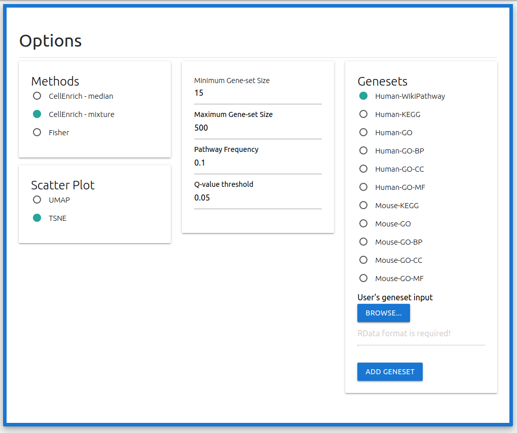

### 2. Scatter Area

[figure not shown]

The left plot is a scatter plot created with `t-SNE` or `U-MAP` and `ggplot2` that the user selected in the option.

- *In this tutorial, the scatter plot is the `t-SNE` result.*
- this scatter plot can be **emphasized** with 3 buttons:
  1. `CELL GROUPS` button ( default ) will colorize as group information.
  2. `FREQUENCY` button will colorize frequently enriched cells in each group.
  3. `ODDS RATIO` button will colorize the enriched cell in each group with the **highest** odds ratio.

The right plot is a histogram plot created with `high charter` to see a distribution of Group / Cell labels.

User can download both result with the `Save` button (LEFT) and `Export` options at the right top (RIGHT).

[figure not shown]

### 3. Pathways Module

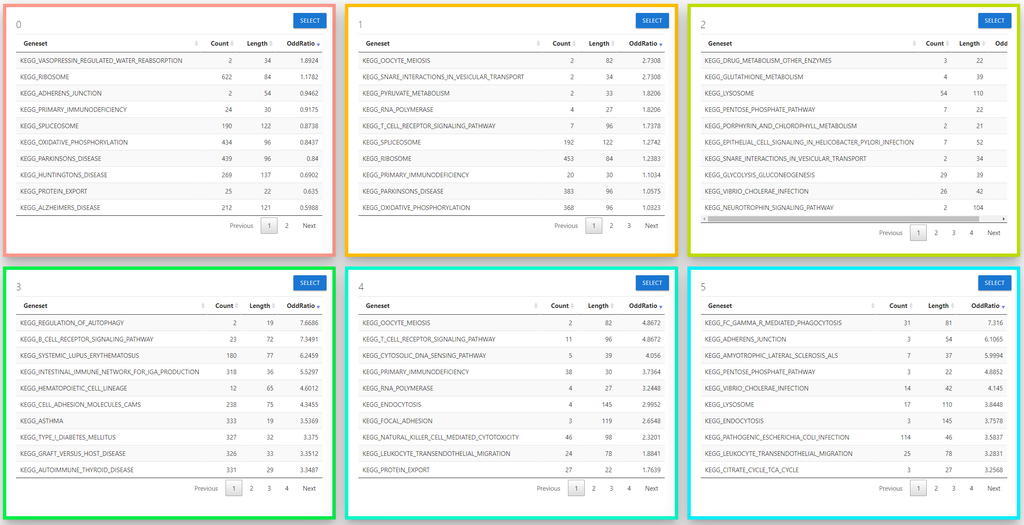

This pathway module will show significant pathways for each group in table format.

To use emphasize feature, a user should clear the `sortable` list with the `CLEARLIST` button.

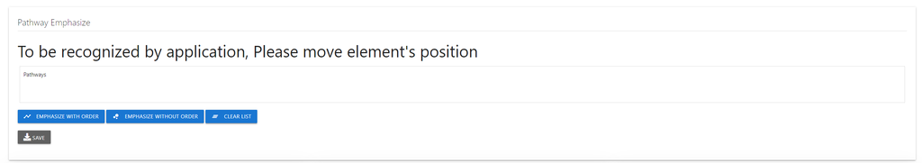

For each group, **only 1 pathway** can be selected for emphasis in a scatter plot.

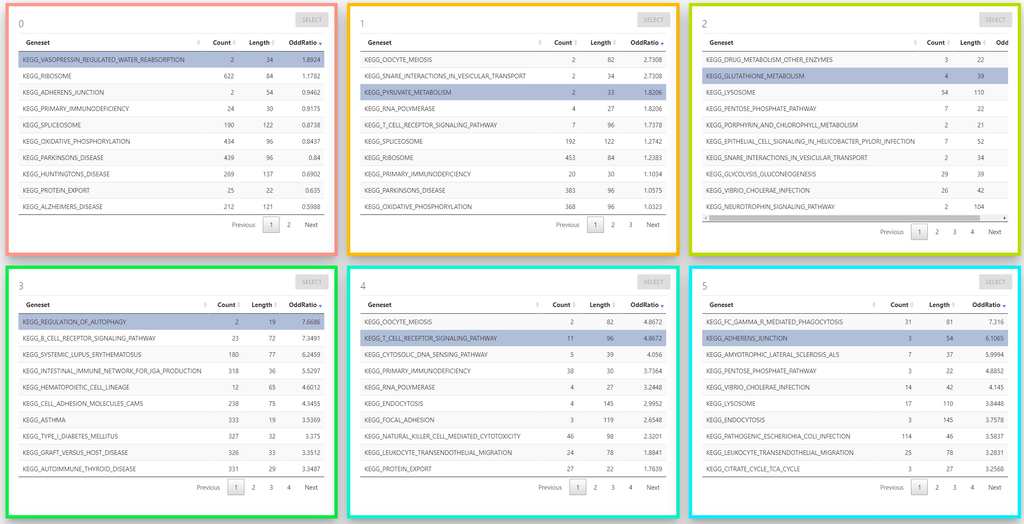

After clicking the ‘EMPHASIZE’ button, top cell enriched by the selected pathways will be shown.

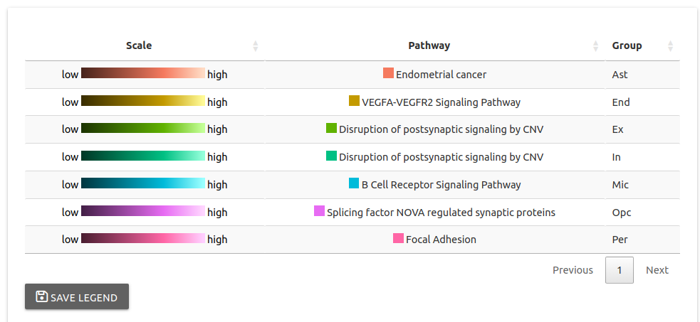

### 4. BiPlot Module

This section shows the BiPlot presentation of the correlation between categories and top significant pathways.

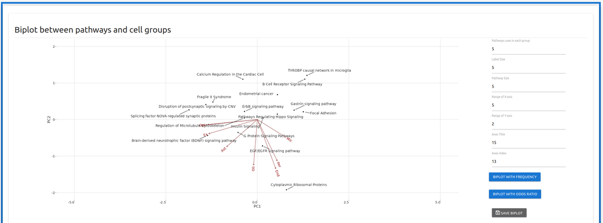

User can check the BiPlot under the perspective of **FREQUENCY** (above) or **ODDS RATIO** (below).

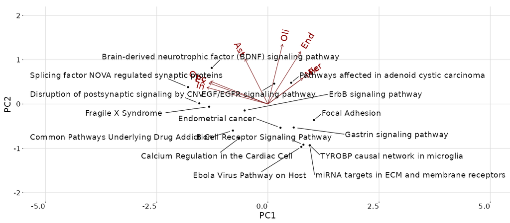

### 5. Marker Module

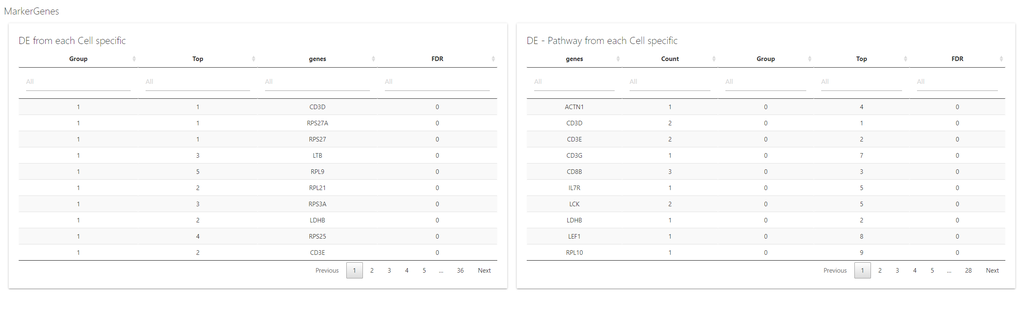

This marker module will show Differentially Expressed genes in the following:

1. Each group ( using findMarker in scran )
2. Each group and pathway-specific ( using Fisher’s exact test )

## License

- Full license
- [MIT](https://opensource.org/licenses/mit-license.php) + file LICENSE

## Developers

- Hai Nguyen  
  Author, maintainer